# Homework 1

Eric Boxer

2018-09-10

### 1. Salary

1. How do the distributions differ by year?

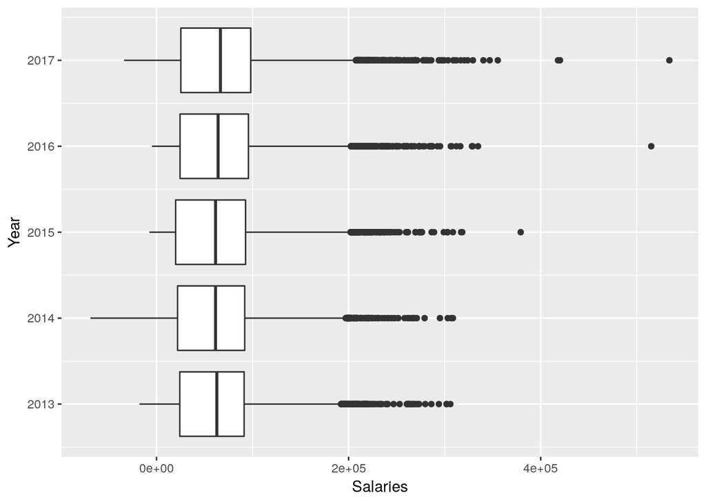

```r
Employee_Compensation <- read_csv("resources/Employee_Compensation.csv")
ggplot(Employee_Compensation,
       mapping = aes(x = Year, y = Salaries, group = Year)) +
  geom_boxplot() +
  coord_flip()
```

From 2013 to 2017, the maximum employees’ salaryies seem to increase. Mean salary and hinge spread look like they may increase slightly. There may be a greater number of high earners, by which I mean those with salaries greater than $200,000, but in a boxplot I cannot be certain about that.

```r
Employee_Compensation %>%
  group_by(Year) %>%
  summarise(mean = mean(Salaries),
            iqr = IQR(Salaries),
            range = max(Salaries) - min(Salaries),
            high_earners = sum(Salaries > 200000),
            perc_high_earners = high_earners / n())
```

```
## # A tibble: 5 x 6
##    Year   mean    iqr   range high_earners perc_high_earners
##   <int>  <dbl>  <dbl>   <dbl>        <int>             <dbl>
## 1  2013 62876. 66972. 323577.          105           0.00266
## 2  2014 61914. 69886. 377404.          132           0.00323
## 3  2015 61969. 72799. 386625.          201           0.00467
## 4  2016 64874. 71178. 519872           338           0.00767
## 5  2017 67062. 72792. 567794.          413           0.00904
```

Summary statistics support some visual findings. An upward trend in mean salary could be the result of automatic wage increases tied to inflation, but the reason behind an increasing number of high earners is non-obvious. Perhaps the total number of employees is going down or staying constant as employees are promoted / earning greater incentives? Is a certain President really ‘draining the swamp’?

```r
Employee_Compensation %>%
  group_by(Year) %>%
  summarise(n = n()) %>%
  mutate(perc_change = n / lag(n))
```

```
## # A tibble: 5 x 3
##    Year     n perc_change
##   <int> <int>       <dbl>
## 1  2013 39476       NA
## 2  2014 40868        1.04
## 3  2015 43078        1.05
## 4  2016 44087        1.02
## 5  2017 45693        1.04
```

Nope, the total number of employees has increased, go figure.

2. What additional information do the histograms provide?

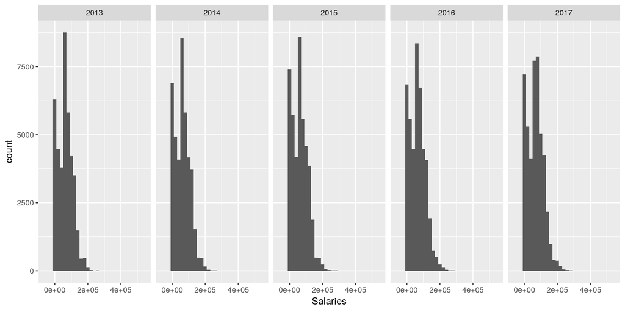

```r
ggplot(Employee_Compensation, mapping = aes(x = Salaries)) +
  geom_histogram(binwidth = 20000) +
  facet_wrap(~ Year, nrow = 1)
```

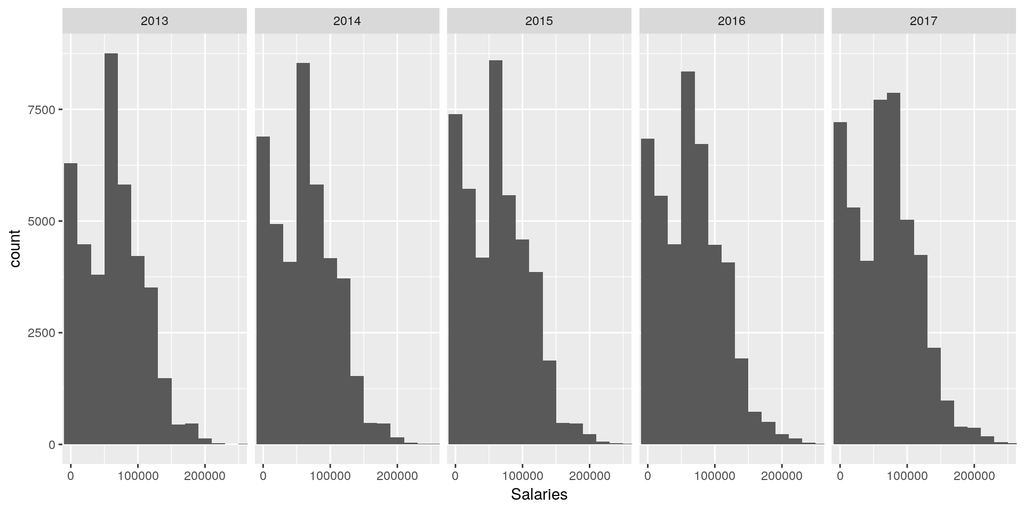

```r
#Cleaned-up version with modified binwidth and xlim cutting off nonvisible outliers
ggplot(Employee_Compensation, mapping = aes(x = Salaries)) +
  geom_histogram(binwidth = 20000) +
  coord_cartesian(xlim = c(0, 250000)) +
  facet_wrap(~ Year, nrow = 1) +
  scale_x_continuous(breaks = c(0, 100000, 200000),
                     labels = c('0', '100000', '200000'))
```

3. What additional information do you learn?

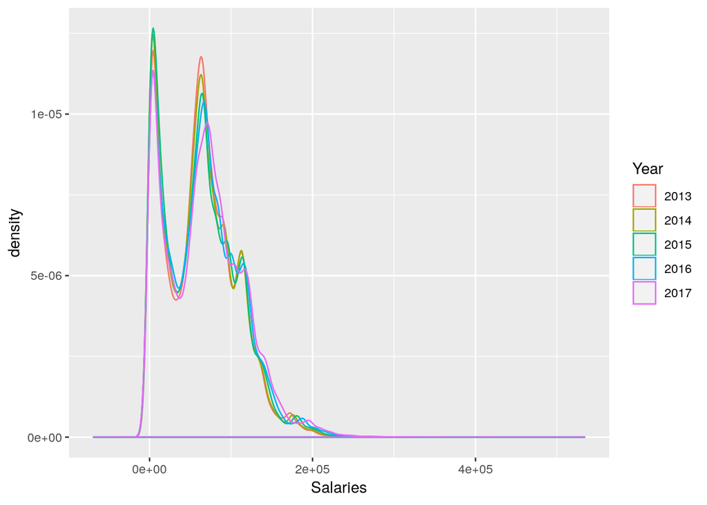

```r
df_Emp_Comp <- data.frame(Employee_Compensation$Salaries)
df_Emp_Comp$Year <- factor(x = Employee_Compensation$Year,
                           levels = c(2013, 2014, 2015, 2016, 2017))
ggplot(df_Emp_Comp, mapping = aes(Employee_Compensation.Salaries, group = Year, color = Year)) +
  geom_density() +
  xlab('Salaries')
```

4. Sum up the results of a), b) and c): what kinds of questions, specific to this dataset, would be best answered about the data by each of the three graphical forms?

### 2. Overtime

1. Why aren’t the boxplots particularly useful?

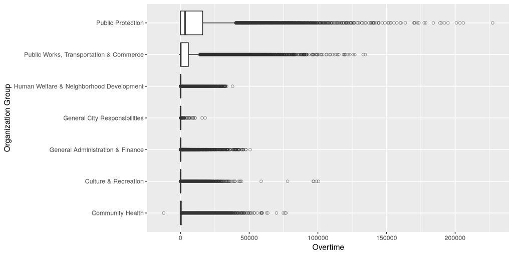

```r
colnames(Employee_Compensation)[4] <- 'Organization_Group'
Employee_Compensation %>%
  ggplot(mapping = aes(x = reorder(Organization_Group, Overtime, FUN = median), y = Overtime)) +
  geom_boxplot(outlier.shape = 1, outlier.alpha = .5) +
  xlab('Organization Group') +
  coord_flip()
```

The boxplots are not particularly useful because data is concentrated at low values of overtime. The hinge-spreads of the groups with the five lowest median overtime values are all very close to zero. As a result, many of the higher values are being treated as outliers and are indistinguishable.  
These boxplots do show that somebody earned a negative overtime value in Community Health. Also, the Public Protection and Public Works, Transportation & Commerce groups display greater hinge-spread and more overtime values over $100,000 than other groups.

```r
#Number of negative overtime values
Employee_Compensation %>%
  filter(Overtime < 0) %>%
  count()
```

```
## # A tibble: 1 x 1
##       n
##   <int>
## 1    32
```

```r
#Which employees earned the most negative overtime value?
Employee_Compensation %>%
  filter(Overtime < -500) %>%
  select(Organization_Group, Department, Overtime)
```

```
## # A tibble: 3 x 3
##   Organization_Group                   Department                 Overtime
##   <chr>                                <chr>                         <dbl>
## 1 Community Health                     DPH Public Health             -612.
## 2 Community Health                     DPH Public Health           -12309.
## 3 Public Works, Transportation & Comm… HHP Hetch Hetchy Water & …   -1073.
```

2. Explain how this form improves on the plots in part a).

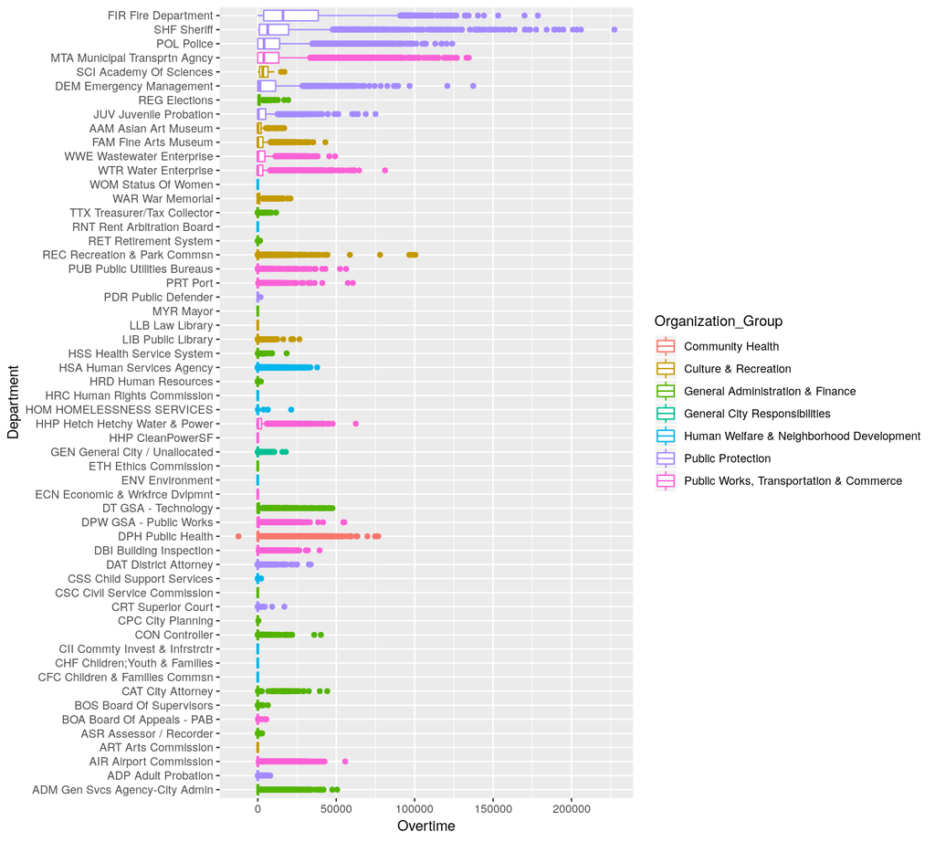

```r
Employee_Compensation %>%
  group_by(Organization_Group, Department) %>%
  ggplot(mapping = aes(x = reorder(Department, Overtime, FUN = median),
                       y = Overtime,
                       color = Organization_Group)) +
  geom_boxplot() +
  xlab('Department') +
  coord_flip()
```

Now we can see that most of the high Overtime earners are in emergency response departments (Fire, Sheriff, Police) and in utilities department (MTA, Water, Public Health, Parks). This could be rationalized by considering that these are workers who are more likely to be on call for time-sensitive problems and are earning more overtime as a result.

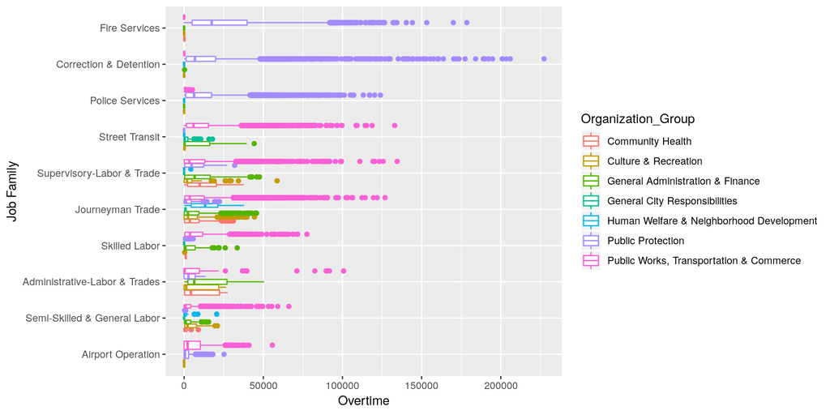

```r
colnames(Employee_Compensation)[10] <- 'Job_Family'
df_Overtime <- Employee_Compensation %>%
  group_by(Job_Family) %>%
  summarise(med_Overtime = median(Overtime)) %>%
  arrange(desc(med_Overtime))
top_Overtime_Jobs <- df_Overtime$Job_Family[1:10]
Employee_Compensation %>%
  group_by(Organization_Group, Job_Family) %>%
  filter(Job_Family %in% top_Overtime_Jobs) %>%
  ggplot(mapping = aes(x = reorder(Job_Family, Overtime, FUN = median), y = Overtime, color = Organization_Group)) +
  geom_boxplot() +
  xlab('Job Family') +
  coord_flip()
```

Public Protection and Public Works, Transportation & Commerce group employees earn the majority of overtime pay in the top 10 job families. Now we can clearly see that workers in jobs categorized as ‘Correction and Detention’ are also earning high Overtime pay. Maybe this could motivate an exploration of understaffed prisons. Are corrections officers being compelled to work overtime in lieu of proper staffing?

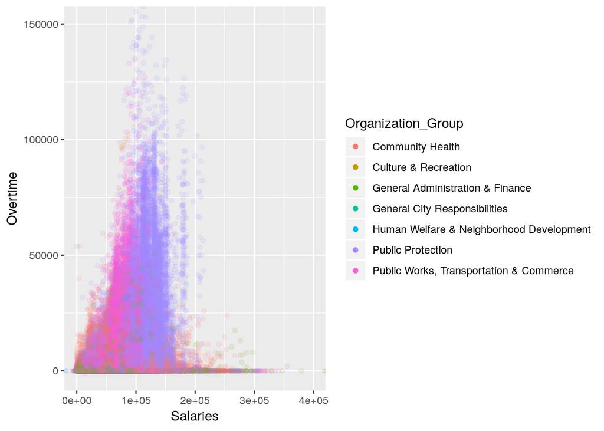

```r
Employee_Compensation %>%
  ggplot(mapping = aes(x = Salaries,
                       y = Overtime,
                       color = Organization_Group)) +
  geom_point(alpha = .1) +
  coord_cartesian(xlim = c(-1000, 400000),
                  ylim = c(-1000, 150000)) +
  guides(color = guide_legend(override.aes = list(alpha = 1)))
```

The employees earning high overtime pay are not earning the most, but many are earning six-figure salaries in addition to overtime pay. This would serve as evidence against an explanation that the high overtime earners are receiving this compensation in exchange for low salaries.